# Avoir des enfants ou pas : une analyse des facteurs décisifs en France (1991-2019) - Partie 3

Mehdi FEHRI

2025-01-17

# Les 4 + 1 hypothèses de Gauss-Markov : Diagnostic et traitement

## Test de **Shapiro-Wilk** :

```r
# Test de Shapiro-Wilk
shapiro_test <- shapiro.test(residus)
cat("Test de Shapiro-Wilk :\n")
```

```
## Test de Shapiro-Wilk :
```

```r
cat("Statistique W :", round(shapiro_test$statistic, 4), "\n")
```

```
## Statistique W : 0.9854
```

```r
cat("P-value :", round(shapiro_test$p.value, 4), "\n")
```

```
## P-value : 0.3699
```

```r
if (shapiro_test$p.value > 0.05) {
  cat("Conclusion : Les résidus suivent une distribution normale (H0 acceptée).\n")
} else {
  cat("Conclusion : Les résidus ne suivent pas une distribution normale (H0 rejetée).\n")
}
```

```
## Conclusion : Les résidus suivent une distribution normale (H0 acceptée).
```

# Hypothèse 1 : Moyenne et Somme des résidus doivent être nulle

Cette vérification, effectuée après les ajustements du modèle, assure que celui-ci respecte cette condition essentielle, renforçant ainsi la **validité** et la **fiabilité** des estimations obtenues.

```r
cat("\n--- Étape 1 : Résidus de moyenne nulle ---\n")
```

```
##
## --- Étape 1 : Résidus de moyenne nulle ---
```

```r
mean_residuals <- mean(residus)
std_error_residuals <- sd(residus) / sqrt(length(residus))
t_stat <- mean_residuals / std_error_residuals
p_value <- 2 * pt(-abs(t_stat), df = length(residus) - 1)

cat("Moyenne des résidus :", round(mean_residuals, 5), "\n")
```

```
## Moyenne des résidus : 0
```

```r
cat("t-statistic :", round(t_stat, 3), " | p-value :", round(p_value, 5), "\n")
```

```
## t-statistic : 0  | p-value : 1
```

```r
if (p_value > 0.05) {
  cat("H₀ est vérifiée : les résidus ont une moyenne nulle.\n")
} else {
  cat("H₀ est rejetée : les résidus n'ont pas une moyenne nulle.\n")
}
```

```
## H₀ est vérifiée : les résidus ont une moyenne nulle.
```

# Hypothèse 2 : Exogénéité

Nous avons, en amont, identifié **6 variables susceptibles d’être endogènes** dans notre analyse, en raison de leur lien potentiel avec le taux de fécondité étudié :

1. **`log_lag_tx_emploifem`** : Le taux de fécondité peut influencer le taux d’emploi des femmes en modifiant leur participation au marché du travail, notamment en raison des responsabilités familiales.
2. **`log_lag_emploi_flex_fem`** : Un taux de fécondité élevé peut accroître le recours des femmes à des formes de travail précaire (CDD, intérim, stages), souvent choisies pour concilier vie professionnelle et parentalité.
3. **`log_lag_spepro_cadrefemmes`** : Un taux de fécondité élevé peut limiter la spécialisation professionnelle des femmes cadres, en réduisant leurs opportunités de carrière ou leur temps alloué à des postes à responsabilité.
4. **`log_lag_loyers`** : Les coûts élevés des loyers peuvent décourager les ménages à avoir plus d’enfants, tout en influençant leur mobilité professionnelle et leur capacité à subvenir à des besoins croissants.
5. **`log_lag_ivg_100`** : Le nombre d’IVG pour 100 naissances reflète des choix reproductifs susceptibles d’être influencés par des contraintes économiques, sociales ou culturelles liées au taux de fécondité.
6. **`log_lag_étude_sup`** : La poursuite d’études supérieures, en particulier chez les femmes, peut être affectée par le taux de fécondité, dans la mesure où des responsabilités parentales peuvent limiter l’accès ou la continuité des études.

Afin de traiter ces **variables endogènes**, nous avons préparé **8 variables instrumentales** pour instrumenter celles suspectées :

1. **`log_lag_depseniors`** : La proportion de la population âgée de 65 ans et plus influence directement le **taux d’emploi des femmes** et leur spécialisation professionnelle, car des responsabilités intergénérationnelles peuvent limiter leur engagement professionnel. Indirectement, cela reflète des pressions démographiques susceptibles d’affecter le taux de fécondité.
2. **`log_lag_lt_interest_rate`** : Le taux d’intérêt à long terme est un indicateur macroéconomique influençant la **poursuite d’études supérieures** (coût des emprunts étudiants, conditions de financement) et les choix de mobilité, y compris le logement. Cela affecte également indirectement les décisions de parentalité.
3. **`log_lag_opi_famille`** : L’opinion sur l’importance de la famille reflète des valeurs sociétales influençant directement le **recours au travail flexible ou précaire** et les **choix reproductifs** des femmes.
4. **`log_lag_opi_work_fem`** : Les opinions sur le travail des femmes influencent directement la **spécialisation professionnelle des femmes cadres** et leur participation au marché de l’emploi. Elles traduisent aussi des normes sociétales qui interagissent avec le taux de fécondité.
5. **`log_lag_pib_hab`** : Le PIB par habitant reflète le développement économique global, influençant directement le **pouvoir d’achat pour le logement** (loyers) et la **poursuite d’études supérieures**. Ce développement peut aussi conditionner indirectement les choix reproductifs.
6. **`log_lag_acceuilenf`** : Le nombre de places d’accueil pour enfants facilite directement l’accès des femmes au **marché de l’emploi** et réduit le recours au travail flexible ou précaire, tout en encourageant indirectement la parentalité.
7. **`log_lag_opi_affaires`** : L’opinion sur le climat des affaires reflète la perception des opportunités économiques, influençant directement la **spécialisation professionnelle des femmes cadres** et le **choix des emplois précaires**.
8. **`log_lag_pa_synthé`** : L’indice de pouvoir d’achat impacte directement les **décisions liées au logement** (prix des loyers) et à la **fécondité**, en déterminant les capacités financières des ménages.

Avant d’utiliser nos instruments, nous avons approfondi l’analyse afin de détecter d’éventuelles **variables endogènes** qui auraient pu nous échapper lors de la première identification.

## Corrélation entre résidus et variables explicatives

```r
correlations <- sapply(variables_explicatives_ols, function(var) {
  cor.test(residus, data_work4_log_out[[var]])$estimate
})
p_values <- sapply(variables_explicatives_ols, function(var) {
  cor.test(residus, data_work4_log_out[[var]])$p.value
})

# Résultats sous forme de tableau
corr_results <- data.frame(
  Variable = variables_explicatives_ols,
  Correlation = correlations,
  P_Value = p_values,
  Significant = p_values <= 0.05
)
print(corr_results)
```

```
##                                                  Variable   Correlation P_Value
## log_lag_tx_emploifem.cor             log_lag_tx_emploifem  1.337451e-16       1
## log_lag_emploi_flex_fem.cor       log_lag_emploi_flex_fem  4.473966e-17       1
## log_lag_bourse.cor                         log_lag_bourse  1.601889e-16       1
## log_lag_opi_inflation.cor           log_lag_opi_inflation  3.455538e-18       1
## log_lag_opi_passée_niv_vie.cor log_lag_opi_passée_niv_vie  4.505575e-17       1
## log_lag_opi_insécurité.cor         log_lag_opi_insécurité  7.329309e-17       1
## log_lag_nuptialite.cor                 log_lag_nuptialite  3.455084e-17       1
## log_lag_spepro_cadrefemmes.cor log_lag_spepro_cadrefemmes -5.762730e-17       1
## log_lag_loyers.cor                         log_lag_loyers  2.438033e-17       1
## log_lag_ivg_100.cor                       log_lag_ivg_100  4.366228e-18       1
## log_lag_étude_sup.cor                   log_lag_étude_sup  4.060028e-17       1
## log_lag_opi_future_niv_vie.cor log_lag_opi_future_niv_vie -1.344274e-17       1
##                                Significant
## log_lag_tx_emploifem.cor             FALSE
## log_lag_emploi_flex_fem.cor          FALSE
## log_lag_bourse.cor                   FALSE
## log_lag_opi_inflation.cor            FALSE
## log_lag_opi_passée_niv_vie.cor       FALSE
## log_lag_opi_insécurité.cor           FALSE
## log_lag_nuptialite.cor               FALSE
## log_lag_spepro_cadrefemmes.cor       FALSE
## log_lag_loyers.cor                   FALSE
## log_lag_ivg_100.cor                  FALSE
## log_lag_étude_sup.cor                FALSE
## log_lag_opi_future_niv_vie.cor       FALSE
```

```r
if (any(corr_results$Significant)) {
  cat("\nCertaines variables explicatives sont significativement corrélées aux résidus. Risque d'endogénéité détecté.\n")
} else {
  cat("\nAucune variable explicative n'est significativement corrélée aux résidus. Pas d'évidence d'endogénéité.\n")
}
```

```
##
## Aucune variable explicative n'est significativement corrélée aux résidus. Pas d'évidence d'endogénéité.
```

## Analyse des résidus croisées

```r
# Régression des variables explicatives sur les résidus
cross_results <- lapply(variables_explicatives_ols, function(var) {
  model_residu <- lm(data_work4_log_out[[var]] ~ residus)
  summary_model <- summary(model_residu)
  data.frame(
    Variable = var,
    Coefficient = coef(summary_model)["residus", "Estimate"],
    P_Value = coef(summary_model)["residus", "Pr(>|t|)"],
    Significant = coef(summary_model)["residus", "Pr(>|t|)"] <= 0.05
  )
}) %>% bind_rows()

print(cross_results)
```

```
##                      Variable   Coefficient P_Value Significant
## 1        log_lag_tx_emploifem  1.385096e-15       1       FALSE
## 2     log_lag_emploi_flex_fem  1.108077e-14       1       FALSE
## 3              log_lag_bourse  3.324231e-14       1       FALSE
## 4       log_lag_opi_inflation  1.385096e-15       1       FALSE
## 5  log_lag_opi_passée_niv_vie  4.847837e-15       1       FALSE
## 6      log_lag_opi_insécurité  0.000000e+00       1       FALSE
## 7          log_lag_nuptialite  2.077644e-15       1       FALSE
## 8  log_lag_spepro_cadrefemmes -5.540385e-15       1       FALSE
## 9              log_lag_loyers -5.540385e-15       1       FALSE
## 10            log_lag_ivg_100  0.000000e+00       1       FALSE
## 11          log_lag_étude_sup -5.540385e-15       1       FALSE
## 12 log_lag_opi_future_niv_vie -6.925481e-16       1       FALSE
```

## TEST DE GRANGER

```r
# Tester la causalité de Granger pour chaque variable explicative et chaque ordre
orders <- 1:4  # Ordres des tests
granger_results <- lapply(variables_explicatives_ols, function(var) {
  lapply(orders, function(order) {
    tryCatch({
      test <- grangertest(data_work4_log_out[[var]] ~ residus, order = order, data = data_work4_log_out)
      data.frame(
        Variable = var,
        Order = order,
        P_Value = test$`Pr(>F)`[2],
        Significant = test$`Pr(>F)`[2] <= 0.05
      )
    }, error = function(e) {
      data.frame(
        Variable = var,
        Order = order,
        P_Value = NA,
        Significant = NA
      )
    })
  }) %>% bind_rows()
}) %>% bind_rows()


# Identifier les variables potentiellement endogènes
potentially_endogenous <- granger_results %>%
  filter(Significant == TRUE) %>%
  distinct(Variable)  # Supprimer les doublons

# Générer un tableau des variables potentiellement endogènes
print(potentially_endogenous)
```

```
##                Variable
## 1 log_lag_opi_inflation
```

**Conclusion** : Selon le **test de causalité de Granger**, une variable apparait comme potentiellement endogènes. Elle ne fait pas partie des variables que nous avions initialement suspectées. Cependant, ces résultats pourraient être influencés par des problématiques d’**autocorrélation**, ce qui nécessite une analyse plus approfondie pour confirmer l’endogénéité réelle de ces variables.

## Analyse des variables potentiellement endogènes

```r
# Nos variables endogènes
cat(paste0("- ", endogenous_vars, collapse = "\n"), "\n\n")
```

```
## - log_lag_tx_emploifem
## - log_lag_emploi_flex_fem
## - log_lag_spepro_cadrefemmes
## - log_lag_loyers
## - log_lag_ivg_100
## - log_lag_étude_sup
```

```r
# Nos variables instrumentales\n")
cat(paste0("- ", instrument_vars, collapse = "\n"), "\n")
```

```
## - log_lag_depseniors
## - log_lag_lt_interest_rate
## - log_lag_opi_famille
## - log_lag_opi_work_fem
## - log_lag_pib_hab
## - log_lag_acceuilenf
## - log_lag_opi_affaires
## - log_lag_pa_synthé
```

## Tests de première étape (First-stage) pour les variables endogènes 2FSLS

```r
if (length(endogenous_vars) > 0) {
  first_stage_summary <- data.frame()

  for (endog in endogenous_vars) {
    # Formule pour la première étape
    first_stage_formula <- as.formula(paste(
      endog, "~",
      paste(c(instrument_vars, setdiff(variables_explicatives, endogenous_vars)), collapse = " + ")
    ))

    # Modèle de première étape
    first_stage_model <- lm(first_stage_formula, data = data_work4_log_out_iv)

    # F-test pour la pertinence des instruments
    instruments_only_formula <- as.formula(paste(endog, "~", paste(instrument_vars, collapse = " + ")))
    instruments_only <- update(first_stage_model, instruments_only_formula)
    f_test <- waldtest(first_stage_model, instruments_only)

    # Stockage des résultats
    first_stage_summary <- rbind(first_stage_summary, data.frame(
      Endogenous_Variable = endog,
      F_statistic = ifelse(!is.null(f_test$F[2]), f_test$F[2], NA),
      F_p_value = ifelse(!is.null(f_test$`Pr(>F)`[2]), f_test$`Pr(>F)`[2], NA),
      R_squared = summary(first_stage_model)$r.squared,
      Adj_R_squared = summary(first_stage_model)$adj.r.squared
    ))
  }

  # Affichage des résultats
  print(first_stage_summary)
} else {
  message("Aucune variable endogène détectée. Pas besoin de modèle IV.")
}
```

```
##          Endogenous_Variable F_statistic    F_p_value R_squared Adj_R_squared
## 1       log_lag_tx_emploifem    27.18539 1.591664e-17 0.9979488     0.9975942
## 2    log_lag_emploi_flex_fem    40.93361 1.515765e-22 0.9894885     0.9876718
## 3 log_lag_spepro_cadrefemmes    26.03219 4.958879e-17 0.9984279     0.9981562
## 4             log_lag_loyers    77.18841 2.026458e-31 0.9990996     0.9989440
## 5            log_lag_ivg_100    18.69979 1.581057e-13 0.9249628     0.9119934
## 6          log_lag_étude_sup    48.59354 7.914484e-25 0.9987385     0.9985204
```

**Analyse des Résultats :**

Lors de la première étape de notre analyse en **moindres carrés en deux étapes** (*2SLS*), nous avons observé que la plupart de nos variables présentaient des **F-statistics** largement supérieures à 10. Cette observation indique que nos variables instrumentales sont fortement corrélées avec les variables endogènes qu’elles sont censées instrumenter, attestant ainsi de leur pertinence.

La pertinence des instruments est cruciale pour garantir des estimations fiables dans les modèles économétriques. Des instruments faibles peuvent conduire à des estimations biaisées et inefficaces. Ainsi, une **F-statistic** supérieure à 10 est souvent utilisée comme seuil empirique pour indiquer la force adéquate des instruments.

Cependant, il est également essentiel de vérifier l’exogénéité des instruments, c’est-à-dire s’assurer qu’ils ne sont pas corrélés avec le terme d’erreur du modèle structurel. Cette double vérification de la pertinence et de l’exogénéité des instruments renforce la validité des estimations obtenues.

En résumé, les **F-statistics** élevées observées lors de la première étape de notre analyse suggèrent que nos instruments sont pertinents, ce qui augmente la confiance dans les résultats de notre modèle, sous réserve que l’exogénéité des instruments soit également confirmée.

## Modèle IV

```r
# Formule IV
formula_iv <- as.formula(paste(
  "fec ~",
  paste(variables_explicatives, collapse = " + "),
  "|",
  paste(c(setdiff(variables_explicatives, endogenous_vars), instrument_vars), collapse = " + ")
))

# Estimation du modèle IV
iv_model <- ivreg(formula_iv, data = data_work4_log_out_iv)

cat("\nRésumé du modèle IV:\n")
```

```
##
## Résumé du modèle IV:
```

```r
print(summary(iv_model))
```

```
##
## Call:
## ivreg(formula = formula_iv, data = data_work4_log_out_iv)
##
## Residuals:
##        Min         1Q     Median         3Q        Max
## -0.0077841 -0.0020303  0.0002358  0.0015088  0.0067943
##
## Coefficients:
##                             Estimate Std. Error t value Pr(>|t|)
## (Intercept)                -1.363824   0.672124  -2.029 0.045650 *
## log_lag_tx_emploifem        0.312611   0.101257   3.087 0.002746 **
## log_lag_emploi_flex_fem     0.068644   0.037282   1.841 0.069166 .
## log_lag_bourse              0.012558   0.005156   2.435 0.017019 *
## log_lag_opi_inflation       0.076724   0.148084   0.518 0.605760
## log_lag_opi_passée_niv_vie -0.023827   0.013533  -1.761 0.081969 .
## log_lag_opi_insécurité      0.007209   0.010849   0.664 0.508240
## log_lag_nuptialite         -0.064854   0.027049  -2.398 0.018746 *
## log_lag_spepro_cadrefemmes  0.192802   0.054393   3.545 0.000649 ***
## log_lag_loyers             -0.300457   0.080735  -3.722 0.000359 ***
## log_lag_ivg_100             0.128999   0.028068   4.596 1.52e-05 ***
## log_lag_étude_sup          -0.126245   0.036111  -3.496 0.000761 ***
## log_lag_opi_future_niv_vie  0.131527   0.066917   1.966 0.052696 .
## ---
## Signif. codes:  0 '***' 0.001 '**' 0.01 '*' 0.05 '.' 0.1 ' ' 1
##
## Residual standard error: 0.002939 on 83 degrees of freedom
## Multiple R-Squared: 0.4933,  Adjusted R-squared:  0.42
## Wald test: 8.684 on 12 and 83 DF,  p-value: 1.87e-10
```

**Analyse des Résultats :**

Le **test de Wald** que nous avons réalisé, avec une valeur de *p* inférieure à 0.05, indique que le modèle global est statistiquement significatif.

Cela confirme que les instruments et les variables explicatives sont collectivement pertinents pour expliquer la variable dépendante, validant ainsi leur pertinence pour corriger l’endogénéité.

## Test de Sargan

```r
# Vérifiez que le modèle IV a été estimé avant de lancer ce test
if (!exists("iv_model")) {
  stop("Le modèle IV n'a pas encore été estimé. Veuillez exécuter le bloc pour l'estimation du modèle IV.")
}

# Test de Sargan
iv_summary <- summary(iv_model, diagnostics = TRUE)
sargan_test <- iv_summary$diagnostics["Sargan", ]

cat("\nTest de Sargan:\n")
```

```
##
## Test de Sargan:
```

```r
print(sargan_test)
```

```
##        df1        df2  statistic    p-value
## 2.00000000         NA 0.05725215 0.97177977
```

```r
cat("\nInterprétation du Test de Sargan:\n")
```

```
##
## Interprétation du Test de Sargan:
```

```r
cat("- Un p-value faible (<0.05) indique que les instruments ne sont pas valides (suridentification non rejetée).\n")
```

```
## - Un p-value faible (<0.05) indique que les instruments ne sont pas valides (suridentification non rejetée).
```

```r
cat("- Un p-value élevé indique que les instruments sont globalement valides.\n")
```

```
## - Un p-value élevé indique que les instruments sont globalement valides.
```

**Analyse des Résultats du Test de Sargan :**

Le **test de Sargan**, également connu sous le nom de test de suridentification, évalue la validité des instruments utilisés dans notre modèle économétrique. Il vérifie si ces instruments sont exogènes, c’est-à-dire non corrélés avec le terme d’erreur du modèle.

**Conclusion :**

Les résultats du test de Sargan indiquent que **nos instruments sont valides**, renforçant ainsi la confiance dans les estimations de notre modèle. Cette validité suggère que les instruments utilisés sont appropriés pour corriger l’endogénéité, assurant des estimations non biaisées et efficaces.

Il est toutefois recommandé de compléter cette analyse par d’autres tests de robustesse pour confirmer la solidité de nos instruments et la fiabilité des conclusions tirées de notre modèle.

## Test de Hausman

```r
ols_model <- lm(as.formula(paste("fec ~", paste(variables_explicatives, collapse = " + "))),
                data = data_work4_log_out_iv)

# Test de Hausman
hausman_results <- try({
  b_iv <- coef(iv_model)
  b_ols <- coef(ols_model)
  common_vars <- intersect(names(b_iv), names(b_ols))

  b_diff <- b_iv[common_vars] - b_ols[common_vars]
  vcov_diff <- vcov(iv_model)[common_vars, common_vars] - vcov(ols_model)[common_vars, common_vars]

  if (det(vcov_diff) == 0) {
    stop("La matrice de variance-covariance est singulière, impossible de calculer le test de Hausman.")
  }

  stat <- as.numeric(t(b_diff) %*% solve(vcov_diff) %*% b_diff)
  p_value <- 1 - pchisq(stat, df = length(common_vars))
  list(statistic = stat, p_value = p_value)
})

if (!inherits(hausman_results, "try-error")) {
  cat("\nTest de Hausman:\n")
  print(hausman_results)
  cat("\nInterprétation du Test de Hausman:\n")
  cat("- Un p-value faible suggère que le modèle OLS est biaisé et que le modèle IV est préférable.\n")
  cat("- Un p-value élevé suggère que le biais d'endogénéité n'est pas significatif, l'OLS pourrait être acceptable.\n")
} else {
  cat("Le test de Hausman n'a pas pu être effectué (matrice non inversible). Vérifiez vos données et instruments.\n")
}
```

```
##
## Test de Hausman:
## $statistic
## [1] 11.55024
##
## $p_value
## [1] 0.5648228
##
##
## Interprétation du Test de Hausman:
## - Un p-value faible suggère que le modèle OLS est biaisé et que le modèle IV est préférable.
## - Un p-value élevé suggère que le biais d'endogénéité n'est pas significatif, l'OLS pourrait être acceptable.
```

**Analyse des Résultats du Test de Hausman :**

Le **test de Hausman** est utilisé pour déterminer si un modèle économétrique souffre d’endogénéité, c’est-à-dire si certaines variables explicatives sont corrélées avec le terme d’erreur. Une endogénéité non corrigée peut biaiser les estimations et conduire à des conclusions erronées.

**Conclusion :**

Les résultats du test de Hausman indiquent que **notre modèle OLS ne souffre pas de problèmes significatifs d’endogénéité**. Par conséquent, il n’est pas nécessaire de recourir à des méthodes d’instrumentation ou à des transformations supplémentaires pour corriger l’endogénéité. Les variables instrumentales que nous avons considérées sont pertinentes, comme le confirment les différents tests effectués, mais leur utilisation n’est pas indispensable dans ce contexte spécifique.

*Il reste toutefois recommandé de rester vigilant quant à la spécification du modèle et de considérer d’autres tests de robustesse pour s’assurer de la fiabilité des estimations obtenues*

## Hypothèse 3 : Homoscédasticité

Nous avons appliqué les tests de **Breusch-Pagan** et de **White** pour détecter l’hétéroscédasticité. Ces tests permettent de vérifier si la variance des erreurs est constante, une condition essentielle pour que les estimateurs des moindres carrés ordinaires (*OLS*) soient efficaces et non biaisés.

**Tests appliqués :**

- **Test de Breusch-Pagan** : Évalue si la variance des erreurs dépend des variables explicatives.
- **Test de White** : Détecte des formes plus générales d’hétéroscédasticité sans spécifier une structure particulière.

Ces approches visent à assurer la validité des inférences statistiques en présence d’hétéroscédasticité, garantissant des estimations fiables et précises.

## Visualisation de la forme de la possible hétéroscédascitité

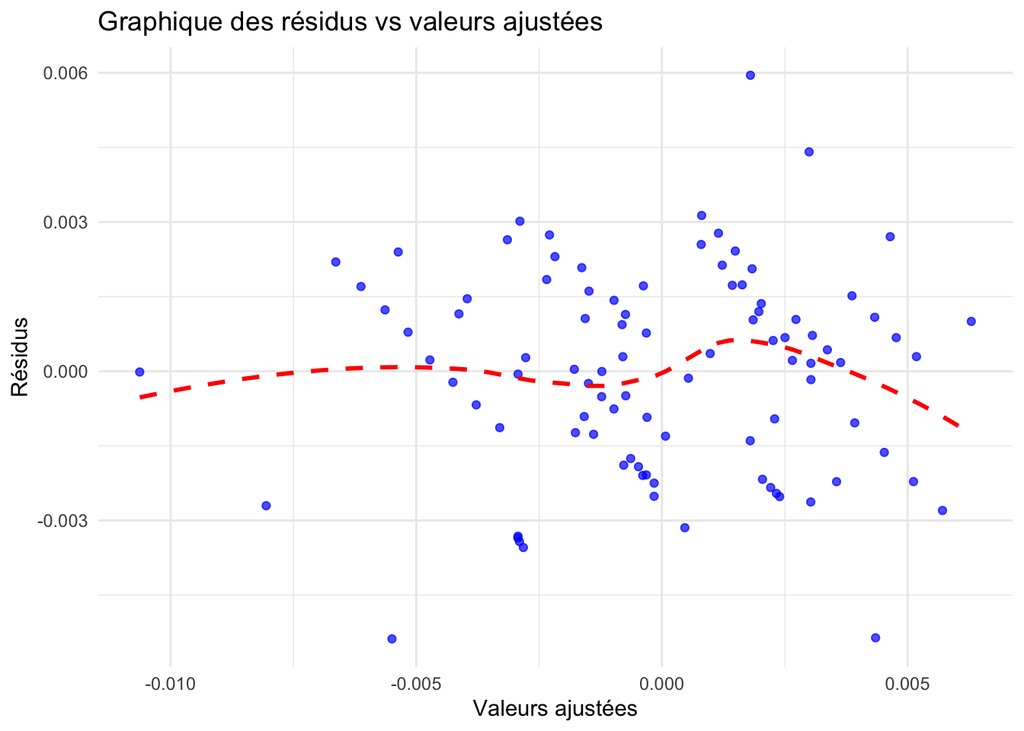

```r
# Résidus vs Valeurs ajustées
ggplot(data.frame(valeurs_ajustees, residus), aes(x = valeurs_ajustees, y = residus)) +
  geom_point(color = "blue", alpha = 0.7) +
  geom_smooth(method = "loess", se = FALSE, color = "red", linetype = "dashed") +
  theme_minimal() +
  labs(
    title = "Graphique des résidus vs valeurs ajustées",
    x = "Valeurs ajustées",
    y = "Résidus"
  )
```

## Test de Breush Pagan

```r
cat("\n--- Test de Breusch-Pagan ---\n")
```

```
##
## --- Test de Breusch-Pagan ---
```

```r
# Détail de la régression auxiliaire
bp_model <- lm(residus^2 ~ ., data = data_work4_log_out[, variables_explicatives_ols])
summary_bp <- summary(bp_model)

cat("\nRésumé de la régression auxiliaire :\n")
```

```
##
## Résumé de la régression auxiliaire :
```

```r
print(summary_bp)
```

```
##
## Call:
## lm(formula = residus^2 ~ ., data = data_work4_log_out[, variables_explicatives_ols])
##
## Residuals:
##        Min         1Q     Median         3Q        Max
## -7.682e-06 -2.980e-06 -7.907e-07  1.315e-06  2.992e-05
##
## Coefficients:
##                              Estimate Std. Error t value Pr(>|t|)
## (Intercept)                 1.653e-03  9.365e-04   1.766   0.0811 .
## log_lag_tx_emploifem       -8.824e-05  1.681e-04  -0.525   0.6011
## log_lag_emploi_flex_fem     8.190e-05  4.303e-05   1.903   0.0605 .
## log_lag_bourse             -6.338e-06  6.609e-06  -0.959   0.3404
## log_lag_opi_inflation      -3.966e-04  1.893e-04  -2.095   0.0392 *
## log_lag_opi_passée_niv_vie -1.918e-05  2.080e-05  -0.922   0.3593
## log_lag_opi_insécurité      3.145e-05  1.752e-05   1.795   0.0763 .
## log_lag_nuptialite          2.848e-05  3.558e-05   0.800   0.4258
## log_lag_spepro_cadrefemmes -2.580e-05  5.703e-05  -0.452   0.6522
## log_lag_loyers              1.654e-04  9.780e-05   1.691   0.0946 .
## log_lag_ivg_100             4.446e-05  4.375e-05   1.016   0.3124
## log_lag_étude_sup           7.808e-06  4.579e-05   0.171   0.8650
## log_lag_opi_future_niv_vie -2.017e-04  8.004e-05  -2.520   0.0136 *
## ---
## Signif. codes:  0 '***' 0.001 '**' 0.01 '*' 0.05 '.' 0.1 ' ' 1
##
## Residual standard error: 5.837e-06 on 83 degrees of freedom
## Multiple R-squared:  0.1831, Adjusted R-squared:  0.06503
## F-statistic: 1.551 on 12 and 83 DF,  p-value: 0.1228
```

```r
# Test de Breusch-Pagan
test_bp <- bptest(model_final)

cat("Statistique du test :", round(test_bp$statistic, 3), "\n")
```

```
## Statistique du test : 17.581
```

```r
cat("P-value :", round(test_bp$p.value, 5), "\n")
```

```
## P-value : 0.12902
```

```r
if (test_bp$p.value > 0.05) {
  cat("H₀ est vérifiée : pas d'évidence d'hétéroscédasticité (Breusch-Pagan).\n")
} else {
  cat("H₀ est rejetée : présence d'hétéroscédasticité (Breusch-Pagan).\n")
}
```

```
## H₀ est vérifiée : pas d'évidence d'hétéroscédasticité (Breusch-Pagan).
```

## Test de White

```r
cat("\n--- Test de White ---\n")
```

```
##
## --- Test de White ---
```

```r
# Régression auxiliaire pour le test de White
white_model <- lm(residus^2 ~ poly(valeurs_ajustees, 2), data = data.frame(residus, fitted(model_final)))
summary_white <- summary(white_model)

cat("\nRésumé de la régression auxiliaire (White) :\n")
```

```
##
## Résumé de la régression auxiliaire (White) :
```

```r
print(summary_white)
```

```
##
## Call:
## lm(formula = residus^2 ~ poly(valeurs_ajustees, 2), data = data.frame(residus,
##     fitted(model_final)))
##
## Residuals:
##        Min         1Q     Median         3Q        Max
## -5.422e-06 -3.661e-06 -2.050e-06  1.348e-06  3.127e-05
##
## Coefficients:
##                             Estimate Std. Error t value Pr(>|t|)
## (Intercept)                4.183e-06  6.222e-07   6.722 1.42e-09 ***
## poly(valeurs_ajustees, 2)1 4.074e-07  6.096e-06   0.067    0.947
## poly(valeurs_ajustees, 2)2 2.324e-06  6.096e-06   0.381    0.704
## ---
## Signif. codes:  0 '***' 0.001 '**' 0.01 '*' 0.05 '.' 0.1 ' ' 1
##
## Residual standard error: 6.096e-06 on 93 degrees of freedom
## Multiple R-squared:  0.001609,   Adjusted R-squared:  -0.01986
## F-statistic: 0.07492 on 2 and 93 DF,  p-value: 0.9279
```

```r
# Statistique de White
white_stat <- summary_white$r.squared * nrow(data_work4_log_out)  # Statistique chi-carré basée sur le R²
white_pval <- pchisq(white_stat, df = 2, lower.tail = FALSE)  # Degré de liberté = 2 (termes quadratiques)

cat("Statistique du test :", round(white_stat, 3), "\n")
```

```
## Statistique du test : 0.154
```

```r
cat("P-value :", round(white_pval, 5), "\n")
```

```
## P-value : 0.92569
```

```r
if (white_pval > 0.05) {
  cat("H₀ est vérifiée : pas d'évidence d'hétéroscédasticité (White).\n")
} else {
  cat("H₀ est rejetée : présence d'hétéroscédasticité (White).\n")
}
```

```
## H₀ est vérifiée : pas d'évidence d'hétéroscédasticité (White).
```

Ainsi, les estimateurs obtenus par la méthode des moindres carrés ordinaires (OLS) restent efficaces et non biaisés, et il n’est pas nécessaire d’apporter des ajustements supplémentaires pour corriger l’hétéroscédasticité.

## Conclusion

```r
cat("\n### Résumé des tests d’hétéroscédasticité ###\n")
```

```
##
## ### Résumé des tests d’hétéroscédasticité ###
```

```r
cat("- Breusch-Pagan : ", ifelse(test_bp$p.value > 0.05, "Homoscédasticité", "Hétéroscédasticité"), "\n")
```

```
## - Breusch-Pagan :  Homoscédasticité
```

```r
cat("- White : ", ifelse(white_pval > 0.05, "Homoscédasticité", "Hétéroscédasticité"), "\n")
```

```
## - White :  Homoscédasticité
```

*Nous constatons que l’hétéroscédasticité observée lors de nos premières régressions a finalement disparu. Ce problème a été résolu principalement grâce à un choix judicieux des variables et à la suppression des outliers*.

# Hypothèse 4 : Non-autocorrélation des erreurs

## Visualisation de la forme d’autocorrélation

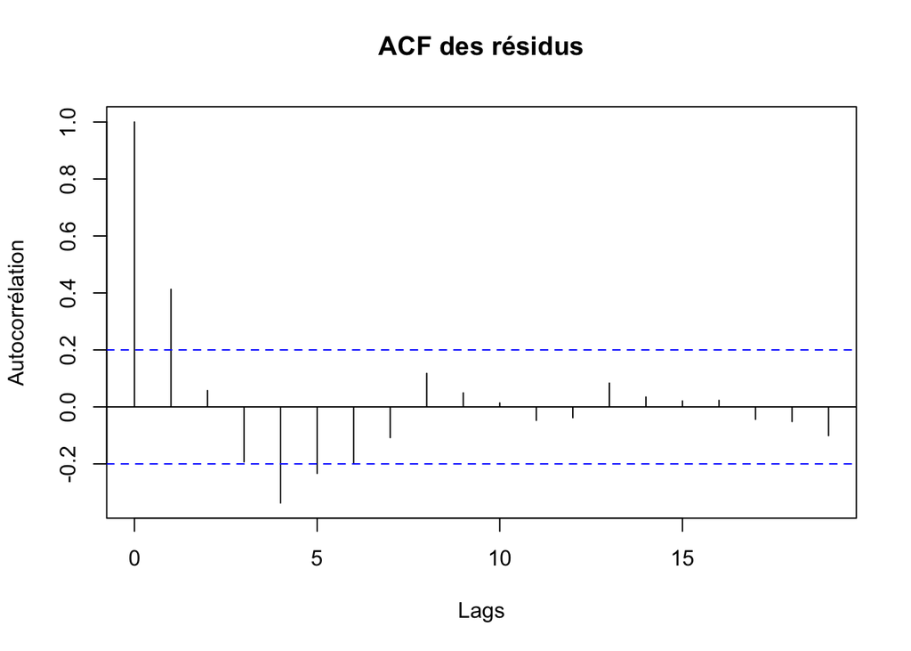

```r
# Visualisation des ACF et PACF
plot(acf_res, main = "ACF des résidus", xlab = "Lags", ylab = "Autocorrélation")
```

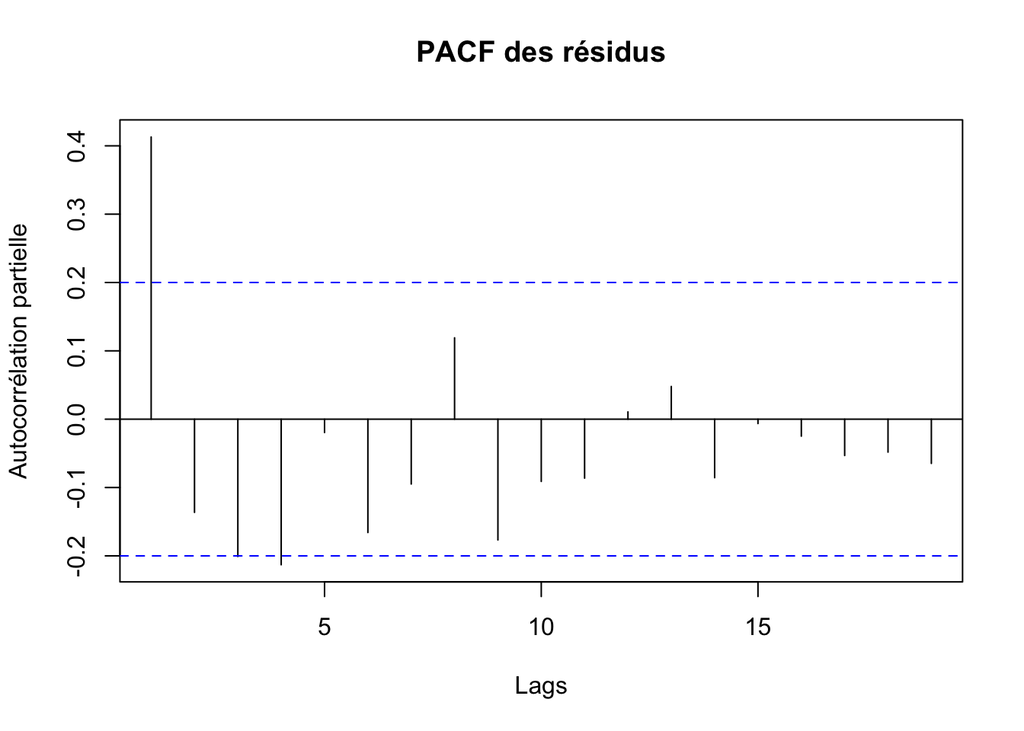

```r
plot(pacf_res, main = "PACF des résidus", xlab = "Lags", ylab = "Autocorrélation partielle")
```

Les résultats de nos tests **ADF** et **PACF** indiquent une autocorrélation significative à plusieurs décalages, révélant une dépendance temporelle structurelle dans les données.

## Test DW, d’odre 1

```r
# Test de Durbin-Watson (autocorrélation d'ordre 1)
cat("\n--- Test Durbin-Watson ---\n")
```

```
##
## --- Test Durbin-Watson ---
```

```r
dw_test <- tryCatch(durbinWatsonTest(model_final), error = function(e) NULL)
print(dw_test)
```

```
##  lag Autocorrelation D-W Statistic p-value
##    1       0.4129268      1.169904       0
##  Alternative hypothesis: rho != 0
```

```r
str(dw_test)
```

```
## List of 4
##  $ r          : num 0.413
##  $ dw         : num 1.17
##  $ p          : num 0
##  $ alternative: chr "two.sided"
##  - attr(*, "class")= chr "durbinWatsonTest"
```

```r
# Interprétation standard
# DW = 2 => Pas d'autocorrélation
# DW < 2 => Autocorrélation positive
# DW > 2 => Autocorrélation négative

if (!is.null(dw_test)) {
  dw_stat <- dw_test$dw    # Extraction de la statistique Durbin-Watson
  dw_p_value <- dw_test$p  # Extraction de la p-value

  cat("Durbin-Watson Statistic :", round(dw_stat, 4), "\n")
  cat("p-value :", round(dw_p_value, 4), "\n")

  if (!is.na(dw_stat)) {
    if (dw_stat < 2) {
      cat("Conclusion : Les résidus suggèrent une autocorrélation positive.\n")
    } else if (dw_stat > 2) {
      cat("Conclusion : Les résidus suggèrent une autocorrélation négative.\n")
    } else {
      cat("Conclusion : Les résidus ne présentent pas d'autocorrélation significative d'ordre 1.\n")
    }
  } else {
    cat("La statistique Durbin-Watson est indisponible (NA).\n")
  }

} else {
  cat("Le test Durbin-Watson n'a pas pu être exécuté.\n")
}
```

```
## Durbin-Watson Statistic : 1.1699
## p-value : 0
## Conclusion : Les résidus suggèrent une autocorrélation positive.
```

Le **test de Durbin-Watson** confirme une autocorrélation des erreurs d’ordre 1. Pour déterminer si cette autocorrélation s’étend à des ordres supérieurs, nous procéderons à des analyses supplémentaires.

## Test Breusch-Goldfrey (d’odre 40 = 10 ans)

```r
cat("\n--- Test d'autocorrélation d'ordre 40 (Breusch-Godfrey) ---\n")
```

```
##
## --- Test d'autocorrélation d'ordre 40 (Breusch-Godfrey) ---
```

```r
bg_test <- tryCatch({
  bgtest(model_final, order = 40)
}, error = function(e) {
  cat("Erreur lors de l'exécution du test de Breusch-Godfrey : ", e$message, "\n")
  return(NULL)
})

if (!is.null(bg_test)) {
  # Afficher tous les détails de l'objet bg_test
  print(bg_test)

  # Extraction des résultats
  bg_stat <- bg_test$statistic
  bg_p_value <- bg_test$p.value
  bg_df <- bg_test$parameter  # Degrés de liberté

  # Affichage détaillé
  cat("\n--- Détails du test de Breusch-Godfrey ---\n")
  cat("Statistique du test :", round(bg_stat, 4), "\n")
  cat("Degrés de liberté :", bg_df, "\n")
  cat("P-value :", round(bg_p_value, 4), "\n")

  # Interprétation du test
  # H0 : Pas d'autocorrélation jusqu'à l'ordre spécifié
  # H1 : Présence d'autocorrélation jusqu'à l'ordre spécifié
  if (bg_p_value > 0.05) {
    cat("Conclusion : Pas d'autocorrélation significative jusqu'à l'ordre 40 (on ne rejette pas H0).\n")
  } else {
    cat("Conclusion : Autocorrélation significative détectée jusqu'à l'ordre 40 (on rejette H0).\n")
  }

  # Ajout d'une recommandation pour améliorer le modèle
  cat("\n--- Recommandation ---\n")
  if (bg_p_value <= 0.05) {
    cat("Il est conseillé d'ajuster un modèle prenant en compte cette autocorrélation, par exemple via un modèle ARIMA ou une correction robuste des erreurs standard.\n")
  } else {
    cat("Le modèle semble adapté du point de vue de l'autocorrélation.\n")
  }
} else {
  cat("Le test Breusch-Godfrey n'a pas pu être exécuté.\n")
}
```

```
##
##  Breusch-Godfrey test for serial correlation of order up to 40
##
## data:  model_final
## LM test = 62.987, df = 40, p-value = 0.01166
##
##
## --- Détails du test de Breusch-Godfrey ---
## Statistique du test : 62.987
## Degrés de liberté : 40
## P-value : 0.0117
## Conclusion : Autocorrélation significative détectée jusqu'à l'ordre 40 (on rejette H0).
##
## --- Recommandation ---
## Il est conseillé d'ajuster un modèle prenant en compte cette autocorrélation, par exemple via un modèle ARIMA ou une correction robuste des erreurs standard.
```

## Conditions pour établir le bon modèle ARIMA - Vérifier la Saisonnalité et la Stationarité

## Check Stationarité KPSS

```r
ts_residuals <- ts(residuals_final, frequency = 4)
cat("\n--- Vérification de la stationnarité (KPSS Test) ---\n")
```

```
##
## --- Vérification de la stationnarité (KPSS Test) ---
```

```r
kpss_test <- kpss.test(ts_residuals)
cat("Statistique KPSS :", round(kpss_test$statistic, 4), "\n")
```

```
## Statistique KPSS : 0.03
```

```r
cat("P-value :", round(kpss_test$p.value, 4), "\n")
```

```
## P-value : 0.1
```

```r
if (kpss_test$p.value > 0.05) {
  cat("Conclusion : Les résidus sont stationnaires selon le test KPSS.\n")
} else {
  cat("Conclusion : Les résidus ne sont pas stationnaires selon le test KPSS.\n")
}
```

```
## Conclusion : Les résidus sont stationnaires selon le test KPSS.
```

```r
# Test de saisonnalité
cat("\n--- Vérification de la saisonnalité ---\n")
```

```
##
## --- Vérification de la saisonnalité ---
```

```r
seasonality_test <- kruskal.test(ts_residuals ~ cycle(ts_residuals))
cat("Statistique du test Kruskal-Wallis :", round(seasonality_test$statistic, 4), "\n")
```

```
## Statistique du test Kruskal-Wallis : 0.9267
```

```r
cat("P-value :", round(seasonality_test$p.value, 4), "\n")
```

```
## P-value : 0.819
```

```r
if (seasonality_test$p.value < 0.05) {
  cat("Conclusion : Les résidus montrent une saisonnalité significative.\n")
} else {
  cat("Conclusion : Pas de saisonnalité significative détectée.\n")
}
```

```
## Conclusion : Pas de saisonnalité significative détectée.
```

Nous avons observé une absence de saisonnalité et la présence d’une stationnarité dans nos données, ce qui nous permet d’utiliser l’autorégression **ARIMA**.

Nous avons opté pour un modèle **ARIMA(4,0,0)**, avec les paramètres suivants :

```r
cat("\n--- Ajustement du modèle ARIMA(4,0,0) ---\n")
```

```
##
## --- Ajustement du modèle ARIMA(4,0,0) ---
```

```r
# Ajustement du modèle ARIMA(4,0,0)
arima_model_400 <- arima(
  residuals_final,
  order = c(4, 0, 0),  # ARIMA(p=4, d=0, q=0)
  include.mean = TRUE  # Inclure une constante si nécessaire
)

# Résumé du modèle ARIMA
cat("\nRésumé du modèle ARIMA(4,0,0) :\n")
```

```
##
## Résumé du modèle ARIMA(4,0,0) :
```

```r
print(summary(arima_model_400))
```

```
##
## Call:
## arima(x = residuals_final, order = c(4, 0, 0), include.mean = TRUE)
##
## Coefficients:
##          ar1      ar2      ar3      ar4  intercept
##       0.3893  -0.0455  -0.1072  -0.2303      0e+00
## s.e.  0.0994   0.1063   0.1117   0.1059      2e-04
##
## sigma^2 estimated as 3.087e-06:  log likelihood = 472.54,  aic = -933.09
##
## Training set error measures:
##                         ME        RMSE         MAE       MPE     MAPE      MASE
## Training set -1.604267e-05 0.001756852 0.001264388 -158.7833 355.0892 0.8997669
##                     ACF1
## Training set 0.005463364
```

```r
# Extraction des résidus corrigés
arima_residuals <- residuals(arima_model_400)
```

Pour évaluer l’efficacité du modèle **ARIMA(4,0,0)** dans la correction de l’autocorrélation, nous analyserons les résidus du modèle ajusté. Une absence d’autocorrélation dans ces résidus indiquerait que le modèle a correctement capturé la structure temporelle des données.

## Graphes ACF/PCF

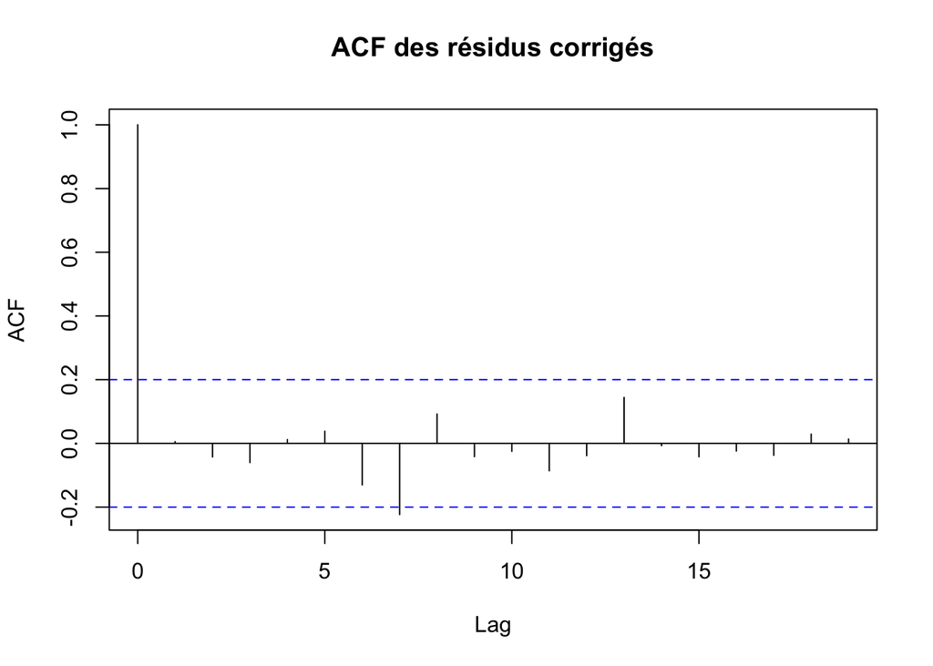

```r
# ACF et PACF des résidus corrigés
acf(arima_residuals, main = "ACF des résidus corrigés")
```

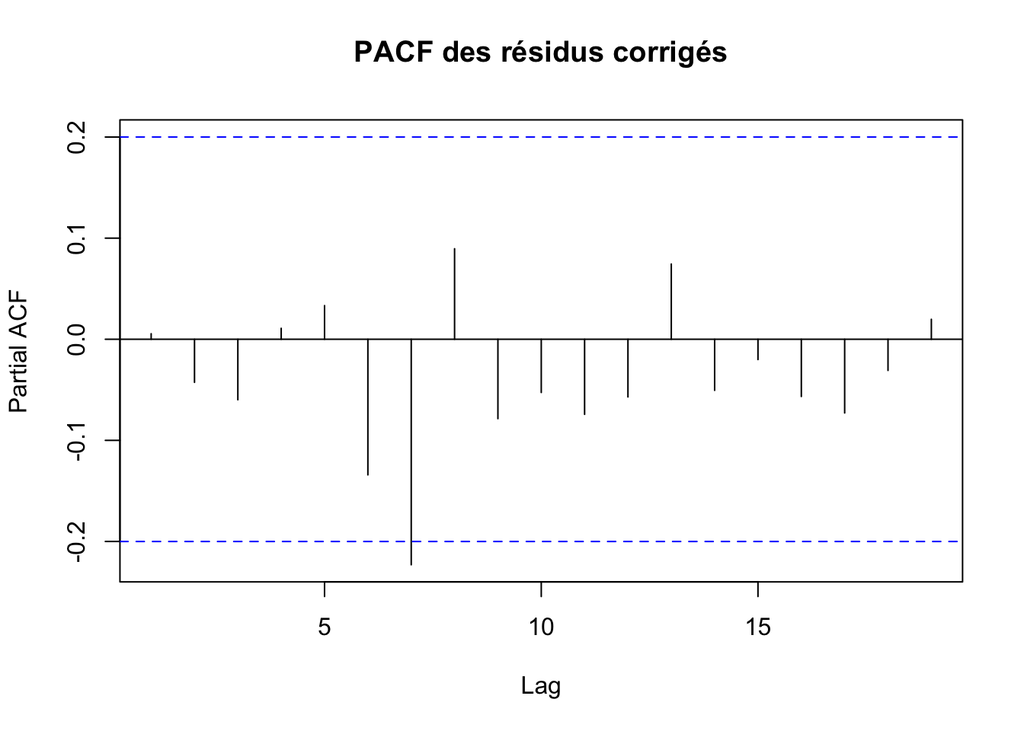

```r
pacf(arima_residuals, main = "PACF des résidus corrigés")
```

Visuellement ça sent très bon !

## Ljung-Box Test sur les résidus corigés

```r
# Test de Ljung-Box sur les résidus corrigés
ljung_box_arima <- Box.test(arima_residuals, lag = 40, type = "Ljung-Box")

cat("Statistique Ljung-Box :", round(ljung_box_arima$statistic, 4), "\n")
```

```
## Statistique Ljung-Box : 31.4399
```

```r
cat("P-value :", round(ljung_box_arima$p.value, 4), "\n")
```

```
## P-value : 0.8313
```

```r
if (ljung_box_arima$p.value > 0.05) {
  cat("Conclusion : Les résidus du modèle ARIMA ne présentent pas d'autocorrélation significative.\n")
} else {
  cat("Conclusion : Les résidus présentent encore une autocorrélation significative. Une révision du modèle ARIMA est nécessaire.\n")
}
```

```
## Conclusion : Les résidus du modèle ARIMA ne présentent pas d'autocorrélation significative.
```

## Test de Dubrin-Watson sur les résidus corrigés

```r
dw_test_corrected <- durbinWatsonTest(lm(arima_residuals ~ 1))

# Affichage des résultats
print(dw_test_corrected)
```

```
##  lag Autocorrelation D-W Statistic p-value
##    1     0.005463364      1.983674    0.91
##  Alternative hypothesis: rho != 0
```

```r
# Interprétation de la p-value
if (dw_test_corrected$p > 0.05) {
  cat("H0 acceptée : Pas d'autocorrélation d'ordre 1 détectée.\n")
} else {
  cat("H0 rejetée : Présence d'autocorrélation d'ordre 1 détectée.\n")
}
```

```
## H0 acceptée : Pas d'autocorrélation d'ordre 1 détectée.
```

**Conclusion :** Les analyses graphiques, ainsi que les tests de **Ljung-Box** et de **Durbin-Watson**, confirment la disparition des problèmes d’autocorrélation. Ainsi, toutes nos hypothèses sont désormais vérifiées.

# VI. Conclusion générale

## Régression finale avec résidus corrigés

```r
# Résumé du nouveau modèle OLS
summary_ols_corrige <- summary(model_final_corrige)
print(summary_ols_corrige)
```

```
##
## Call:
## lm(formula = formule_ols, data = data_work_final_auto)
##
## Residuals:
##        Min         1Q     Median         3Q        Max
## -0.0053810 -0.0014559  0.0002217  0.0014332  0.0059504
##
## Coefficients:
##                              Estimate Std. Error t value Pr(>|t|)
## (Intercept)                -1.3567073  0.3528741  -3.845 0.000236 ***
## log_lag_tx_emploifem        0.3298554  0.0633586   5.206 1.37e-06 ***
## log_lag_emploi_flex_fem     0.0297938  0.0162163   1.837 0.069749 .
## log_lag_bourse              0.0061497  0.0024903   2.469 0.015582 *
## log_lag_opi_inflation      -0.0482118  0.0713483  -0.676 0.501093
## log_lag_opi_passée_niv_vie -0.0201023  0.0078389  -2.564 0.012136 *
## log_lag_opi_insécurité      0.0008462  0.0066024   0.128 0.898326
## log_lag_nuptialite         -0.0047327  0.0134069  -0.353 0.724982
## log_lag_spepro_cadrefemmes  0.1028937  0.0214902   4.788 7.26e-06 ***
## log_lag_loyers             -0.1821771  0.0368513  -4.944 3.94e-06 ***
## log_lag_ivg_100             0.1739499  0.0164863  10.551  < 2e-16 ***
## log_lag_étude_sup          -0.0317902  0.0172542  -1.842 0.068977 .
## log_lag_opi_future_niv_vie  0.0706104  0.0301585   2.341 0.021614 *
## ---
## Signif. codes:  0 '***' 0.001 '**' 0.01 '*' 0.05 '.' 0.1 ' ' 1
##
## Residual standard error: 0.0022 on 83 degrees of freedom
## Multiple R-squared:  0.7162, Adjusted R-squared:  0.6752
## F-statistic: 17.46 on 12 and 83 DF,  p-value: < 2.2e-16
```

## Comparaison des coefficients OLS avant et après correction de l’autocorrélation.

```r
print(comparaison_coeff)
```

```
##                            Coefficients_anciens Coefficients_corriges
## (Intercept)                       -1.3567073340         -1.3567073340
## log_lag_tx_emploifem               0.3298553957          0.3298553957
## log_lag_emploi_flex_fem            0.0297937657          0.0297937657
## log_lag_bourse                     0.0061497483          0.0061497483
## log_lag_opi_inflation             -0.0482118263         -0.0482118263
## log_lag_opi_passée_niv_vie        -0.0201023175         -0.0201023175
## log_lag_opi_insécurité             0.0008462214          0.0008462214
## log_lag_nuptialite                -0.0047326659         -0.0047326659
## log_lag_spepro_cadrefemmes         0.1028937088          0.1028937088
## log_lag_loyers                    -0.1821771060         -0.1821771060
## log_lag_ivg_100                    0.1739499027          0.1739499027
## log_lag_étude_sup                 -0.0317902393         -0.0317902393
## log_lag_opi_future_niv_vie         0.0706104025          0.0706104025
```

# Inférence finale

Après avoir vérifié que les hypothèses classiques (Gauss-Markov et normalité des résidus) étaient satisfaites, nous disposons désormais d’un modèle final fiable, permettant d’effectuer des inférences valables sur la variation du taux de fécondité, considérée hors tendance. Il est important de rappeler que 50,44 % de la variation du taux de fécondité est expliquée par une tendance à long terme, et que l’objectif de cette étude s’est concentré sur la part inexploitée et inexpliquée des fluctuations à court terme. La variable dépendante (**‘fec’**) représente la variation périodique de la natalité, et les variables explicatives sont transformées en logarithmes, facilitant une interprétation directe en termes d’élasticité.

Sur le plan statistique, le modèle présente un **R²** d’environ 0,72 (R² ajusté à 0,68), ce qui indique un pouvoir explicatif raisonnable des fluctuations de la fécondité à court terme, indépendamment de la tendance à long terme. L’interprétation en élasticité suggère qu’une variation de 1 % d’une variable explicative entraîne, *ceteris paribus*, une variation proportionnelle de la fécondité selon le coefficient estimé.

## Résultats empiriques

Concernant les résultats empiriques, plusieurs variables se révèlent particulièrement significatives :

- **Impact positif** :
  - **Taux d’emploi des femmes** : Contrairement aux idées reçues, une augmentation du taux d’emploi des femmes est associée à une hausse significative de la fécondité. Cela pourrait s’expliquer par un meilleur équilibre entre vie professionnelle et familiale, favorisé par des politiques de soutien (congés parentaux, crèches, flexibilité) qui permettent aux femmes actives de prendre des décisions parentales plus sereines aujourd’hui.
  - **Performance de la bourse** : Une amélioration des performances boursières favorise la fécondité, probablement en raison de son rôle comme indicateur de confiance économique, incitant les ménages à envisager des projets à long terme, tels que la parentalité.
  - **IVG pour 100 naissances** : Bien que surprenant et contre-intuitif, une hausse du recours à l’IVG est positivement corrélée avec la fécondité. Cela peut refléter des conditions où un meilleur accès à la contraception et aux services de santé reproductive (comme dans les pays scandinaves) permet aux individus de planifier leurs grossesses de manière plus réfléchie, conduisant à un environnement familial plus favorable pour élever des enfants.
  - **Opinion sur le futur niveau de vie** : Une perception optimiste du niveau de vie futur favorise la fécondité, car les attentes économiques positives incitent les ménages à envisager la parentalité dans un cadre perçu comme stable et sécurisant.
  - **Spécialisation professionnelle des femmes cadres** : Une augmentation de la proportion de femmes cadres est associée à une hausse de la fécondité. Cela peut sembler contre-intuitif, mais un contexte où de plus en plus de femmes occupent des postes qualifiés peut refléter des environnements de travail plus inclusifs et favorables à la conciliation vie professionnelle-vie familiale (télétravail, congés adaptés). En outre, les femmes cadres, bénéficiant d’une meilleure sécurité économique et de ressources suffisantes, peuvent se sentir davantage en mesure de fonder une famille.
- **Impact négatif** :
  - **Prix des loyers** : Une augmentation des prix des loyers est fortement corrélée à une baisse de la fécondité, soulignant que les contraintes liées au logement jouent un rôle clé dans les décisions reproductives, notamment dans les zones où l’accès à des logements abordables est limité.
  - **Opinion sur le niveau de vie passé** : Une perception d’amélioration du niveau de vie au cours des dix dernières années est associée à une baisse de la fécondité. Cela pourrait indiquer que les individus ayant connu une ascension sociale ou économique récente préfèrent investir dans d’autres priorités (éducation, carrière, patrimoine) au lieu de s’engager dans des projets parentaux.
- **Variables marginalement significatives** :
  - **Emploi précaire (CDD, Intérim etc..)** : L’augmentation de la proportion d’emplois précaires est positivement liée à la fécondité, mais sa significativité reste marginale. Cela pourrait refléter que certains ménages s’adaptent en choisissant des emplois plus flexibles pour équilibrer leurs responsabilités familiales.
  - **Études supérieures** : Une hausse de la proportion de personnes ayant poursuivi des études supérieures est associée à une légère baisse de la fécondité, bien que la significativité soit faible. Cela pourrait refléter des choix différés de parentalité en raison des coûts d’opportunité élevés.
- **Variables non significatives** :
  - **Opinion sur l’inflation** et **opinion sur l’insécurité** : Ces variables ne montrent pas d’effet significatif sur la variation de la fécondité.
  - **Taux de nuptialité** : L’absence d’impact significatif du taux de nuptialité pourrait refléter la séparation croissante entre mariage et décisions parentales.

## Limites du modèle

*Malgré sa robustesse*, le modèle présente certaines limites :

- **Généralisation incertaine** : Les résultats, issus d’un contexte temporel et géographique spécifique, ne sont pas nécessairement extrapolables à d’autres situations.
- **Sélection des variables explicatives** : Bien que les variables incluses soient économiquement pertinentes, d’autres facteurs non observés pourraient jouer un rôle dans la dynamique de la fécondité.

## Conclusion

En définitive, ce travail met en évidence l’influence de divers déterminants économiques et sociaux sur la variation hors tendance du taux de fécondité et propose un cadre analytique solide pour en comprendre les mécanismes. Toutefois, il convient de rester prudent quant à la portée des résultats, qui dépendent de la qualité des hypothèses, de la disponibilité des données et de la spécificité du contexte étudié.